# HIV-Microbiome: Script for Figure S1

Khoi Nguyen - nguyenkhoibiotech@gmail.com

23 December, 2023

# Figure S1-A

```r
# Model 1: Outcome =  Drug + weight.gain_cat + BMI_cat + Age_cat + Sex

 Y.list = c("PCo1", "PCo2",
            "Log2.A/P", "Log2.B/P", "Log2.F/B",
            "Phylo.diver",  "InvSimpson", "Observed ASV", "Shannon")
model = list()
model.sum = list()
for (i in Y.list) {
  model[[i]] = lm(E.PCoA1[,i] ~   Drug + weight.gain_cat + BMI_cat + Age_cat + Sex, data = E.PCoA1)
  model.sum[[i]] =  summary(model[[i]])
  model.sum[[i]] = cbind(model.sum[[i]]$coefficients[,c("Estimate", "Std. Error", "Pr(>|t|)" ) ], model.sum[[i]]$adj.r.squared) %>% as.data.frame()
  colnames(model.sum[[i]])[4] = "adj.R-squared"
  model.sum[[i]] =  mutate(model.sum[[i]], overall.p =  overall_p(model[[i]]))
  model.sum[[i]] =  mutate(model.sum[[i]], AIC =  AICc(model[[i]])) %>% round(7)
  model.sum[[i]] =  mutate(model.sum[[i]], dependent.var = i)
  model.sum[[i]] =  mutate(model.sum[[i]], predictors = rownames(model.sum[[i]]))
  model.sum[[i]] =  mutate(model.sum[[i]], var.P.adj = p.adjust(model.sum[[i]]$`Pr(>|t|)`, method = "fdr" ))
  model.sum[[i]] <- mutate(model.sum[[i]], star = cut(model.sum[[i]]$var.P.adj, breaks=c(-Inf, 0.001, 0.01, 0.05, 0.1, Inf), label=c("***", "**",  "*", "+", "")))
  model.sum[[i]]   = model.sum[[i]][-1,]
}
Model1 = do.call("rbind", model.sum) %>% mutate(No.model = "model1")
Model1 = Model1  %>% mutate(
                    New.Predictors = case_when(predictors == "DrugDTG" ~ "Drug: DTG",
                                               predictors == "DrugOther" ~ "Drug: Other",
                                               predictors == "BMI_catobese" ~ "BMI_cat: obese",
                                               predictors == "BMI_catoverweight" ~ "BMI_cat: overweight",
                                               predictors == "Age_catyoung" ~ "Age_cat: young",
                                               predictors == "SexM" ~ "Sex: M",
                                               predictors == "weight.gain_catlose" ~ "Weight loss"))
row.names(Model1) = paste(Model1$predictors, Model1$dependent.var,"Model1", sep = "_")
```

```r
knitr::kable(Model1,
             row.names = F, align="c")  %>%
  kable_styling(bootstrap_options = c("striped", "hover", "condensed", "responsive")) %>%
  row_spec(which(Model1$var.P.adj < 0.05), bold = T, color = "Seagreen")
```

Estimate

Std. Error

Pr(>|t|)

adj.R-squared

overall.p

AIC

dependent.var

predictors

var.P.adj

star

No.model

New.Predictors

0.0718939

0.0489548

0.1447013

0.3477956

0.0000000

-6.390776

PCo1

DrugDTG

0.2315221

model1

Drug: DTG

0.1275257

0.0863110

0.1422950

0.3477956

0.0000000

-6.390776

PCo1

DrugOther

0.2315221

model1

Drug: Other

-0.0016250

0.0428431

0.9698110

0.3477956

0.0000000

-6.390776

PCo1

weight.gain_catlose

0.9698110

model1

Weight loss

-0.0134714

0.0557480

0.8094873

0.3477956

0.0000000

-6.390776

PCo1

BMI_catobese

0.9251283

model1

BMI_cat: obese

-0.1136866

0.0479582

0.0194409

0.3477956

0.0000000

-6.390776

PCo1

BMI_catoverweight

0.0518424

model1

BMI_cat: overweight

0.0136377

0.0424176

0.7484127

0.3477956

0.0000000

-6.390776

PCo1

Age_catyoung

0.9251283

model1

Age_cat: young

-0.3324128

0.0441515

0.0000000

0.3477956

0.0000000

-6.390776

PCo1

SexM

0.0000000

***

model1

Sex: M

-0.0424798

0.0355564

0.2346781

0.0139505

0.2844805

-84.416223

PCo2

DrugDTG

0.4693562

model1

Drug: DTG

-0.0780799

0.0626886

0.2154951

0.0139505

0.2844805

-84.416223

PCo2

DrugOther

0.4693562

model1

Drug: Other

0.0326691

0.0311174

0.2960010

0.0139505

0.2844805

-84.416223

PCo2

weight.gain_catlose

0.4736016

model1

Weight loss

0.0677120

0.0404904

0.0972079

0.0139505

0.2844805

-84.416223

PCo2

BMI_catobese

0.4693562

model1

BMI_cat: obese

-0.0132189

0.0348326

0.7050249

0.0139505

0.2844805

-84.416223

PCo2

BMI_catoverweight

0.7120631

model1

BMI_cat: overweight

-0.0478839

0.0308084

0.1228970

0.0139505

0.2844805

-84.416223

PCo2

Age_catyoung

0.4693562

model1

Age_cat: young

-0.0118653

0.0320678

0.7120631

0.0139505

0.2844805

-84.416223

PCo2

SexM

0.7120631

model1

Sex: M

0.6521874

0.8126878

0.4239297

0.2895412

0.0000001

679.114896

Log2.A/P

DrugDTG

0.6782875

model1

Drug: DTG

2.6890111

1.4328290

0.0631140

0.2895412

0.0000001

679.114896

Log2.A/P

DrugOther

0.2304035

model1

Drug: Other

0.4479161

0.7112282

0.5300999

0.2895412

0.0000001

679.114896

Log2.A/P

weight.gain_catlose

0.7067999

model1

Weight loss

0.1256418

0.9254596

0.8922492

0.2895412

0.0000001

679.114896

Log2.A/P

BMI_catobese

0.8922492

model1

BMI_cat: obese

-1.3770417

0.7961437

0.0864013

0.2895412

0.0000001

679.114896

Log2.A/P

BMI_catoverweight

0.2304035

model1

BMI_cat: overweight

-0.2830821

0.7041646

0.6884285

0.2895412

0.0000001

679.114896

Log2.A/P

Age_catyoung

0.7867754

model1

Age_cat: young

-4.6860459

0.7329498

0.0000000

0.2895412

0.0000001

679.114896

Log2.A/P

SexM

0.0000000

***

model1

Sex: M

1.3981780

1.1299121

0.2184732

0.3249283

0.0000000

759.524635

Log2.B/P

DrugDTG

0.3495571

model1

Drug: DTG

2.5967393

1.9921190

0.1950284

0.3249283

0.0000000

759.524635

Log2.B/P

DrugOther

0.3495571

model1

Drug: Other

-0.3326288

0.9888488

0.7372029

0.3249283

0.0000000

759.524635

Log2.B/P

weight.gain_catlose

0.8425176

model1

Weight loss

0.1918871

1.2867032

0.8817139

0.3249283

0.0000000

759.524635

Log2.B/P

BMI_catobese

0.8817139

model1

BMI_cat: obese

-2.8597310

1.1069101

0.0110437

0.3249283

0.0000000

759.524635

Log2.B/P

BMI_catoverweight

0.0294499

model1

BMI_cat: overweight

0.4385244

0.9790280

0.6550624

0.3249283

0.0000000

759.524635

Log2.B/P

Age_catyoung

0.8425176

model1

Age_cat: young

-7.1084205

1.0190492

0.0000000

0.3249283

0.0000000

759.524635

Log2.B/P

SexM

0.0000000

***

model1

Sex: M

0.0939198

0.2896807

0.7463668

0.0285194

0.1716640

427.412387

Log2.F/B

DrugDTG

0.8897737

model1

Drug: DTG

0.7924067

0.5107286

0.1235484

0.0285194

0.1716640

427.412387

Log2.F/B

DrugOther

0.3294624

model1

Drug: Other

-0.1054071

0.2535157

0.6783517

0.0285194

0.1716640

427.412387

Log2.F/B

weight.gain_catlose

0.8897737

model1

Weight loss

-0.6596047

0.3298780

0.0479281

0.0285194

0.1716640

427.412387

Log2.F/B

BMI_catobese

0.2077000

model1

BMI_cat: obese

0.0394177

0.2837836

0.8897737

0.0285194

0.1716640

427.412387

Log2.F/B

BMI_catoverweight

0.8897737

model1

BMI_cat: overweight

0.0822368

0.2509979

0.7437853

0.0285194

0.1716640

427.412387

Log2.F/B

Age_catyoung

0.8897737

model1

Age_cat: young

-0.5131986

0.2612583

0.0519250

0.0285194

0.1716640

427.412387

Log2.F/B

SexM

0.2077000

model1

Sex: M

11.0768427

16.8169083

0.5114339

0.0427475

0.0996335

1418.384417

Phylo.diver

DrugDTG

0.7462573

model1

Drug: DTG

11.8119015

29.6494602

0.6910915

0.0427475

0.0996335

1418.384417

Phylo.diver

DrugOther

0.7898189

model1

Drug: Other

-12.3758450

14.7174109

0.4021653

0.0427475

0.0996335

1418.384417

Phylo.diver

weight.gain_catlose

0.7462573

model1

Weight loss

-22.8312787

19.1504905

0.2356573

0.0427475

0.0996335

1418.384417

Phylo.diver

BMI_catobese

0.6284195

model1

BMI_cat: obese

9.6378853

16.4745619

0.5596930

0.0427475

0.0996335

1418.384417

Phylo.diver

BMI_catoverweight

0.7462573

model1

BMI_cat: overweight

-0.0375946

14.5712433

0.9979459

0.0427475

0.0996335

1418.384417

Phylo.diver

Age_catyoung

0.9979459

model1

Age_cat: young

39.3820513

15.1668938

0.0106557

0.0427475

0.0996335

1418.384417

Phylo.diver

SexM

0.0426228

model1

Sex: M

4.8692313

2.8861015

0.0943127

0.0028007

0.4015793

988.339736

InvSimpson

DrugDTG

0.3669272

model1

Drug: DTG

0.2830653

5.0884116

0.9557344

0.0028007

0.4015793

988.339736

InvSimpson

DrugOther

0.9557344

model1

Drug: Other

0.8631274

2.5257878

0.7331862

0.0028007

0.4015793

988.339736

InvSimpson

weight.gain_catlose

0.8379271

model1

Weight loss

-3.6574699

3.2865886

0.2681153

0.0028007

0.4015793

988.339736

InvSimpson

BMI_catobese

0.5362306

model1

BMI_cat: obese

-1.4648693

2.8273483

0.6053876

0.0028007

0.4015793

988.339736

InvSimpson

BMI_catoverweight

0.8071835

model1

BMI_cat: overweight

3.7393162

2.5007026

0.1375977

0.0028007

0.4015793

988.339736

InvSimpson

Age_catyoung

0.3669272

model1

Age_cat: young

-1.8304931

2.6029276

0.4833375

0.0028007

0.4015793

988.339736

InvSimpson

SexM

0.7733400

model1

Sex: M

11.0768427

16.8169083

0.5114339

0.0427475

0.0996335

1418.384417

Observed ASV

DrugDTG

0.7462573

model1

Drug: DTG

11.8119015

29.6494602

0.6910915

0.0427475

0.0996335

1418.384417

Observed ASV

DrugOther

0.7898189

model1

Drug: Other

-12.3758450

14.7174109

0.4021653

0.0427475

0.0996335

1418.384417

Observed ASV

weight.gain_catlose

0.7462573

model1

Weight loss

-22.8312787

19.1504905

0.2356573

0.0427475

0.0996335

1418.384417

Observed ASV

BMI_catobese

0.6284195

model1

BMI_cat: obese

9.6378853

16.4745619

0.5596930

0.0427475

0.0996335

1418.384417

Observed ASV

BMI_catoverweight

0.7462573

model1

BMI_cat: overweight

-0.0375946

14.5712433

0.9979459

0.0427475

0.0996335

1418.384417

Observed ASV

Age_catyoung

0.9979459

model1

Age_cat: young

39.3820513

15.1668938

0.0106557

0.0427475

0.0996335

1418.384417

Observed ASV

SexM

0.0426228

model1

Sex: M

0.1513314

0.1209053

0.2132587

-0.0132261

0.6099953

214.212064

Shannon

DrugDTG

0.4265174

model1

Drug: DTG

0.1641156

0.2131650

0.4429522

-0.0132261

0.6099953

214.212064

Shannon

DrugOther

0.7087235

model1

Drug: Other

-0.0215424

0.1058109

0.8390344

-0.0132261

0.6099953

214.212064

Shannon

weight.gain_catlose

0.8390344

model1

Weight loss

-0.2020610

0.1376826

0.1449704

-0.0132261

0.6099953

214.212064

Shannon

BMI_catobese

0.4265174

model1

BMI_cat: obese

-0.0531167

0.1184440

0.6546768

-0.0132261

0.6099953

214.212064

Shannon

BMI_catoverweight

0.7482021

model1

BMI_cat: overweight

0.1465868

0.1047601

0.1644494

-0.0132261

0.6099953

214.212064

Shannon

Age_catyoung

0.4265174

model1

Age_cat: young

-0.0534187

0.1090425

0.6251542

-0.0132261

0.6099953

214.212064

Shannon

SexM

0.7482021

model1

Sex: M

```r
# Model 2: Outcome = Drug + weight.gain_cat + BMI_cat + Age_cat + Ethnicity
 Y.list = c("PCo1", "PCo2", "Log2.A/P", "Log2.B/P", "Log2.F/B", "Phylo.diver",  "InvSimpson", "Observed ASV", "Shannon")
model = list()
model.sum = list()
for (i in Y.list) {
  model[[i]] = lm(E.PCoA1[,i] ~   Drug + weight.gain_cat + BMI_cat + Age_cat + Ethnicity, data = E.PCoA1)
  model.sum[[i]] =  summary(model[[i]])
  model.sum[[i]] = cbind(model.sum[[i]]$coefficients[,c("Estimate", "Std. Error", "Pr(>|t|)" ) ], model.sum[[i]]$adj.r.squared) %>% as.data.frame()
  colnames(model.sum[[i]])[4] = "adj.R-squared"
  model.sum[[i]] =  mutate(model.sum[[i]], overall.p =  overall_p(model[[i]]))
  model.sum[[i]] =  mutate(model.sum[[i]], AIC =  AICc(model[[i]])) %>% round(7)
  model.sum[[i]] =  mutate(model.sum[[i]], dependent.var = i)
  model.sum[[i]] =  mutate(model.sum[[i]], predictors = rownames(model.sum[[i]]))
  model.sum[[i]] =  mutate(model.sum[[i]], var.P.adj = p.adjust(model.sum[[i]]$`Pr(>|t|)`, method = "fdr" ))
  model.sum[[i]] <- mutate(model.sum[[i]], star = cut(model.sum[[i]]$var.P.adj, breaks=c(-Inf, 0.001, 0.01, 0.05, 0.1, Inf), label=c("***", "**",  "*", "+", "")))
  model.sum[[i]]   = model.sum[[i]][-1,]
}
Model2 = do.call("rbind", model.sum) %>% mutate(No.model = "model2")
Model2 = Model2  %>% mutate(
                    New.Predictors = case_when(predictors == "DrugDTG" ~ "Drug: DTG",
                                               predictors == "DrugOther" ~ "Drug: Other",
                                               predictors == "BMI_catobese" ~ "BMI_cat: obese",
                                               predictors == "BMI_catoverweight" ~ "BMI_cat: overweight",
                                               predictors == "Age_catyoung" ~ "Age_cat: young",
                                               predictors == "EthnicityCaucasian" ~ "Ethnicity: Caucasian",
                                               predictors == "weight.gain_catlose" ~ "Weight loss"))
row.names(Model2) = paste(Model2$predictors, Model2$dependent.var,"Model2", sep = "_")
```

```r
knitr::kable(Model2,
             row.names = F, align="c")  %>%
  kable_styling(bootstrap_options = c("striped", "hover", "condensed", "responsive")) %>%
  row_spec(which(Model2$var.P.adj < 0.05), bold = T, color = "Seagreen")
```

Estimate

Std. Error

Pr(>|t|)

adj.R-squared

overall.p

AIC

dependent.var

predictors

var.P.adj

star

No.model

New.Predictors

0.1024747

0.0533059

0.0570524

0.2306773

0.0000038

13.75782

PCo1

DrugDTG

0.1521397

model2

Drug: DTG

0.1169442

0.0941303

0.2166514

0.2306773

0.0000038

13.75782

PCo1

DrugOther

0.4257373

model2

Drug: Other

0.0516787

0.0467224

0.2710203

0.2306773

0.0000038

13.75782

PCo1

weight.gain_catlose

0.4257373

model2

Weight loss

0.0112923

0.0602618

0.8516895

0.2306773

0.0000038

13.75782

PCo1

BMI_catobese

0.8516895

model2

BMI_cat: obese

-0.1034492

0.0520817

0.0494011

0.2306773

0.0000038

13.75782

PCo1

BMI_catoverweight

0.1521397

model2

BMI_cat: overweight

0.0227607

0.0461168

0.6225779

0.2306773

0.0000038

13.75782

PCo1

Age_catyoung

0.7115176

model2

Age_cat: young

-0.2600056

0.0469258

0.0000002

0.2306773

0.0000038

13.75782

PCo1

EthnicityCaucasian

0.0000016

***

model2

Ethnicity: Caucasian

-0.0480710

0.0349060

0.1711627

0.0545743

0.0613299

-89.54891

PCo2

DrugDTG

0.4564339

model2

Drug: DTG

-0.0593228

0.0616388

0.3378723

0.0545743

0.0613299

-89.54891

PCo2

DrugOther

0.5403321

model2

Drug: Other

0.0255585

0.0305949

0.4052491

0.0545743

0.0613299

-89.54891

PCo2

weight.gain_catlose

0.5403321

model2

Weight loss

0.0844118

0.0394609

0.0345588

0.0545743

0.0613299

-89.54891

PCo2

BMI_catobese

0.1382352

model2

BMI_cat: obese

-0.0008686

0.0341044

0.9797265

0.0545743

0.0613299

-89.54891

PCo2

BMI_catoverweight

0.9797265

model2

BMI_cat: overweight

-0.0342779

0.0301984

0.2587191

0.0545743

0.0613299

-89.54891

PCo2

Age_catyoung

0.5174382

model2

Age_cat: young

0.0689930

0.0307282

0.0266795

0.0545743

0.0613299

-89.54891

PCo2

EthnicityCaucasian

0.1382352

model2

Ethnicity: Caucasian

1.1058796

0.8526918

0.1972749

0.2218914

0.0000068

690.21142

Log2.A/P

DrugDTG

0.2630332

model2

Drug: DTG

2.4751489

1.5057264

0.1029677

0.2218914

0.0000068

690.21142

Log2.A/P

DrugOther

0.2059354

model2

Drug: Other

1.2298147

0.7473798

0.1026209

0.2218914

0.0000068

690.21142

Log2.A/P

weight.gain_catlose

0.2059354

model2

Weight loss

0.4212650

0.9639589

0.6629268

0.2218914

0.0000068

690.21142

Log2.A/P

BMI_catobese

0.7576306

model2

BMI_cat: obese

-1.2732448

0.8331096

0.1292071

0.2218914

0.0000068

690.21142

Log2.A/P

BMI_catoverweight

0.2067314

model2

BMI_cat: overweight

-0.1993750

0.7376930

0.7874426

0.2218914

0.0000068

690.21142

Log2.A/P

Age_catyoung

0.7874426

model2

Age_cat: young

-3.9299557

0.7506349

0.0000008

0.2218914

0.0000068

690.21142

Log2.A/P

EthnicityCaucasian

0.0000064

***

model2

Ethnicity: Caucasian

2.0222027

1.2344349

0.1041454

0.1983930

0.0000303

780.48419

Log2.B/P

DrugDTG

0.2777211

model2

Drug: DTG

2.4561385

2.1798276

0.2622109

0.1983930

0.0000303

780.48419

Log2.B/P

DrugOther

0.4488165

model2

Drug: Other

0.7668760

1.0819755

0.4799117

0.1983930

0.0000303

780.48419

Log2.B/P

weight.gain_catlose

0.5713427

model2

Weight loss

0.7922595

1.3955153

0.5713427

0.1983930

0.0000303

780.48419

Log2.B/P

BMI_catobese

0.5713427

model2

BMI_cat: obese

-2.5871476

1.2060859

0.0340689

0.1983930

0.0000303

780.48419

Log2.B/P

BMI_catoverweight

0.1362756

model2

BMI_cat: overweight

0.6930776

1.0679521

0.5176578

0.1983930

0.0000303

780.48419

Log2.B/P

Age_catyoung

0.5713427

model2

Age_cat: young

-5.2095610

1.0866879

0.0000050

0.1983930

0.0000303

780.48419

Log2.B/P

EthnicityCaucasian

0.0000400

***

model2

Ethnicity: Caucasian

0.1934801

0.2748666

0.4829270

0.1298314

0.0016163

413.97600

Log2.F/B

DrugDTG

0.7726832

model2

Drug: DTG

0.6261817

0.4853733

0.1996256

0.1298314

0.0016163

413.97600

Log2.F/B

DrugOther

0.5323349

model2

Drug: Other

0.0474897

0.2409191

0.8440856

0.1298314

0.0016163

413.97600

Log2.F/B

weight.gain_catlose

0.9741981

model2

Weight loss

-0.7452637

0.3107337

0.0180897

0.1298314

0.0016163

413.97600

Log2.F/B

BMI_catobese

0.0723588

model2

BMI_cat: obese

-0.0386587

0.2685542

0.8857931

0.1298314

0.0016163

413.97600

Log2.F/B

BMI_catoverweight

0.9741981

model2

BMI_cat: overweight

-0.0077081

0.2377965

0.9741981

0.1298314

0.0016163

413.97600

Log2.F/B

Age_catyoung

0.9741981

model2

Age_cat: young

-1.0145560

0.2419684

0.0000547

0.1298314

0.0016163

413.97600

Log2.F/B

EthnicityCaucasian

0.0004376

***

model2

Ethnicity: Caucasian

9.3679775

17.3287197

0.5898352

-0.0111875

0.5817441

1425.07166

Phylo.diver

DrugDTG

0.8046817

model2

Drug: DTG

7.5847718

30.5999295

0.8046817

-0.0111875

0.5817441

1425.07166

Phylo.diver

DrugOther

0.8046817

model2

Drug: Other

-16.1092565

15.1885292

0.2911046

-0.0111875

0.5817441

1425.07166

Phylo.diver

weight.gain_catlose

0.7762789

model2

Weight loss

-30.2952498

19.5899305

0.1247626

-0.0111875

0.5817441

1425.07166

Phylo.diver

BMI_catobese

0.4990504

model2

BMI_cat: obese

4.9921964

16.9307628

0.7686375

-0.0111875

0.5817441

1425.07166

Phylo.diver

BMI_catoverweight

0.8046817

model2

BMI_cat: overweight

-4.9223194

14.9916709

0.7432592

-0.0111875

0.5817441

1425.07166

Phylo.diver

Age_catyoung

0.8046817

model2

Age_cat: young

8.3837738

15.2546801

0.5836777

-0.0111875

0.5817441

1425.07166

Phylo.diver

EthnicityCaucasian

0.8046817

model2

Ethnicity: Caucasian

5.4934615

2.8089069

0.0529438

0.0602810

0.0480585

981.09663

InvSimpson

DrugDTG

0.1411835

model2

Drug: DTG

-1.0803928

4.9601099

0.8279616

0.0602810

0.0480585

981.09663

InvSimpson

DrugOther

0.8279616

model2

Drug: Other

1.7714488

2.4619918

0.4732939

0.0602810

0.0480585

981.09663

InvSimpson

weight.gain_catlose

0.5409073

model2

Weight loss

-4.5999102

3.1754390

0.1501970

0.0602810

0.0480585

981.09663

InvSimpson

BMI_catobese

0.3003940

model2

BMI_cat: obese

-2.2259901

2.7443999

0.4189969

0.0602810

0.0480585

981.09663

InvSimpson

BMI_catoverweight

0.5409073

model2

BMI_cat: overweight

2.8836935

2.4300819

0.2378268

0.0602810

0.0480585

981.09663

InvSimpson

Age_catyoung

0.3805229

model2

Age_cat: young

-6.7708600

2.4727145

0.0071694

0.0602810

0.0480585

981.09663

InvSimpson

EthnicityCaucasian

0.0286776

model2

Ethnicity: Caucasian

9.3679775

17.3287197

0.5898352

-0.0111875

0.5817441

1425.07166

Observed ASV

DrugDTG

0.8046817

model2

Drug: DTG

7.5847718

30.5999295

0.8046817

-0.0111875

0.5817441

1425.07166

Observed ASV

DrugOther

0.8046817

model2

Drug: Other

-16.1092565

15.1885292

0.2911046

-0.0111875

0.5817441

1425.07166

Observed ASV

weight.gain_catlose

0.7762789

model2

Weight loss

-30.2952498

19.5899305

0.1247626

-0.0111875

0.5817441

1425.07166

Observed ASV

BMI_catobese

0.4990504

model2

BMI_cat: obese

4.9921964

16.9307628

0.7686375

-0.0111875

0.5817441

1425.07166

Observed ASV

BMI_catoverweight

0.8046817

model2

BMI_cat: overweight

-4.9223194

14.9916709

0.7432592

-0.0111875

0.5817441

1425.07166

Observed ASV

Age_catyoung

0.8046817

model2

Age_cat: young

8.3837738

15.2546801

0.5836777

-0.0111875

0.5817441

1425.07166

Observed ASV

EthnicityCaucasian

0.8046817

model2

Ethnicity: Caucasian

0.1722890

0.1188581

0.1499335

0.0258230

0.1892847

209.41726

Shannon

DrugDTG

0.2998670

model2

Drug: DTG

0.1164780

0.2098856

0.5800096

0.0258230

0.1892847

209.41726

Shannon

DrugOther

0.6628681

model2

Drug: Other

0.0086617

0.1041785

0.9338841

0.0258230

0.1892847

209.41726

Shannon

weight.gain_catlose

0.9338841

model2

Weight loss

-0.2360508

0.1343678

0.0816452

0.0258230

0.1892847

209.41726

Shannon

BMI_catobese

0.2177205

model2

BMI_cat: obese

-0.0802438

0.1161285

0.4909753

0.0258230

0.1892847

209.41726

Shannon

BMI_catoverweight

0.6546337

model2

BMI_cat: overweight

0.1161705

0.1028282

0.2609518

0.0258230

0.1892847

209.41726

Shannon

Age_catyoung

0.4175229

model2

Age_cat: young

-0.2296960

0.1046322

0.0301706

0.0258230

0.1892847

209.41726

Shannon

EthnicityCaucasian

0.1206824

model2

Ethnicity: Caucasian

```r
# Model 3: Outcome = BackBone + weight.gain_cat + BMI_cat + Age_cat + Sex
 Y.list = c("PCo1", "PCo2",
            "Log2.A/P", "Log2.B/P", "Log2.F/B",
            "Phylo.diver",  "InvSimpson", "Observed ASV", "Shannon")
model = list()
model.sum = list()
for (i in Y.list) {

  model[[i]] = lm(E.PCoA1[,i] ~   BackBone + weight.gain_cat + BMI_cat + Age_cat + Sex, data = E.PCoA1)

  model.sum[[i]] =  summary(model[[i]])
  model.sum[[i]] = cbind(model.sum[[i]]$coefficients[,c("Estimate", "Std. Error", "Pr(>|t|)" ) ], model.sum[[i]]$adj.r.squared) %>% as.data.frame()
  colnames(model.sum[[i]])[4] = "adj.R-squared"
  model.sum[[i]] =  mutate(model.sum[[i]], overall.p =  overall_p(model[[i]]))
  model.sum[[i]] =  mutate(model.sum[[i]], AIC =  AICc(model[[i]])) %>% round(7)
  model.sum[[i]] =  mutate(model.sum[[i]], dependent.var = i)
  model.sum[[i]] =  mutate(model.sum[[i]], predictors = rownames(model.sum[[i]]))
  model.sum[[i]] =  mutate(model.sum[[i]], var.P.adj = p.adjust(model.sum[[i]]$`Pr(>|t|)`, method = "fdr" ))
  model.sum[[i]] <- mutate(model.sum[[i]], star = cut(model.sum[[i]]$var.P.adj, breaks=c(-Inf, 0.001, 0.01, 0.05, 0.1, Inf), label=c("***", "**",  "*", "+", "")))
  model.sum[[i]]   = model.sum[[i]][-1,]
}
Model3 = do.call("rbind", model.sum) %>% mutate(No.model = "model3")
Model3 = Model3  %>% mutate(
                    New.Predictors = case_when(predictors == "BackBoneTAF" ~ "BackBone: TAF",
                                               predictors == "BMI_catobese" ~ "BMI_cat: obese",
                                               predictors == "BMI_catoverweight" ~ "BMI_cat: overweight",
                                               predictors == "Age_catyoung" ~ "Age_cat: young",
                                               predictors == "SexM" ~ "Sex: M",
                                               predictors == "weight.gain_catlose" ~ "Weight loss"))
row.names(Model3) = paste(Model3$predictors, Model3$dependent.var,"Model3", sep = "_")
```

```r
knitr::kable(Model3,
             row.names = F, align="c")  %>%
  kable_styling(bootstrap_options = c("striped", "hover", "condensed", "responsive")) %>%
  row_spec(which(Model3$var.P.adj < 0.05), bold = T, color = "Seagreen")
```

Estimate

Std. Error

Pr(>|t|)

adj.R-squared

overall.p

AIC

dependent.var

predictors

var.P.adj

star

No.model

New.Predictors

-0.0340883

0.0449079

0.4493628

0.3396730

0.0000000

-6.148067

PCo1

BackBoneTAF

0.7863849

model3

BackBone: TAF

0.0137352

0.0419648

0.7440344

0.3396730

0.0000000

-6.148067

PCo1

weight.gain_catlose

0.9324263

model3

Weight loss

-0.0047385

0.0557617

0.9324263

0.3396730

0.0000000

-6.148067

PCo1

BMI_catobese

0.9324263

model3

BMI_cat: obese

-0.1180047

0.0479687

0.0153798

0.3396730

0.0000000

-6.148067

PCo1

BMI_catoverweight

0.0358862

model3

BMI_cat: overweight

0.0050181

0.0424995

0.9062150

0.3396730

0.0000000

-6.148067

PCo1

Age_catyoung

0.9324263

model3

Age_cat: young

-0.3370932

0.0442731

0.0000000

0.3396730

0.0000000

-6.148067

PCo1

SexM

0.0000000

***

model3

Sex: M

0.0283981

0.0324587

0.3834512

0.0113466

0.2953601

-85.361778

PCo2

BackBoneTAF

0.7378651

model3

BackBone: TAF

0.0244614

0.0303315

0.4216372

0.0113466

0.2953601

-85.361778

PCo2

weight.gain_catlose

0.7378651

model3

Weight loss

0.0624376

0.0403036

0.1240858

0.0113466

0.2953601

-85.361778

PCo2

BMI_catobese

0.5395596

model3

BMI_cat: obese

-0.0094936

0.0346710

0.7847146

0.0113466

0.2953601

-85.361778

PCo2

BMI_catoverweight

0.9155004

model3

BMI_cat: overweight

-0.0440630

0.0307179

0.1541599

0.0113466

0.2953601

-85.361778

PCo2

Age_catyoung

0.5395596

model3

Age_cat: young

-0.0089888

0.0319998

0.7792910

0.0113466

0.2953601

-85.361778

PCo2

SexM

0.9155004

model3

Sex: M

-0.0627973

0.7489659

0.9333251

0.2740010

0.0000001

680.487400

Log2.A/P

BackBoneTAF

0.9333251

model3

BackBone: TAF

0.7447155

0.6998821

0.2895313

0.2740010

0.0000001

680.487400

Log2.A/P

weight.gain_catlose

0.6755730

model3

Weight loss

0.3142223

0.9299841

0.7360702

0.2740010

0.0000001

680.487400

Log2.A/P

BMI_catobese

0.8587486

model3

BMI_cat: obese

-1.5126285

0.8000141

0.0611739

0.2740010

0.0000001

680.487400

Log2.A/P

BMI_catoverweight

0.2141086

model3

BMI_cat: overweight

-0.4612183

0.7087988

0.5165354

0.2740010

0.0000001

680.487400

Log2.A/P

Age_catyoung

0.7231496

model3

Age_cat: young

-4.7983508

0.7383784

0.0000000

0.2740010

0.0000001

680.487400

Log2.A/P

SexM

0.0000000

***

model3

Sex: M

-0.6082602

1.0341275

0.5575603

0.3196549

0.0000000

759.206660

Log2.B/P

BackBoneTAF

0.9252801

model3

BackBone: TAF

-0.0171752

0.9663555

0.9858506

0.3196549

0.0000000

759.206660

Log2.B/P

weight.gain_catlose

0.9858506

model3

Weight loss

0.3703789

1.2840667

0.7735276

0.3196549

0.0000000

759.206660

Log2.B/P

BMI_catobese

0.9252801

model3

BMI_cat: obese

-2.9469093

1.1046118

0.0087365

0.3196549

0.0000000

759.206660

Log2.B/P

BMI_catoverweight

0.0203852

model3

BMI_cat: overweight

0.2572927

0.9786671

0.7930972

0.3196549

0.0000000

759.206660

Log2.B/P

Age_catyoung

0.9252801

model3

Age_cat: young

-7.2048172

1.0195089

0.0000000

0.3196549

0.0000000

759.206660

Log2.B/P

SexM

0.0000000

***

model3

Sex: M

0.0588547

0.2658290

0.8251731

0.0157165

0.2529430

427.742396

Log2.F/B

BackBoneTAF

0.9851698

model3

BackBone: TAF

-0.0206660

0.2484078

0.9338419

0.0157165

0.2529430

427.742396

Log2.F/B

weight.gain_catlose

0.9851698

model3

Weight loss

-0.6035029

0.3300774

0.0700862

0.0157165

0.2529430

427.742396

Log2.F/B

BMI_catobese

0.2453017

model3

BMI_cat: obese

-0.0052895

0.2839474

0.9851698

0.0157165

0.2529430

427.742396

Log2.F/B

BMI_catoverweight

0.9851698

model3

BMI_cat: overweight

0.0296992

0.2515726

0.9062308

0.0157165

0.2529430

427.742396

Log2.F/B

Age_catyoung

0.9851698

model3

Age_cat: young

-0.5478459

0.2620712

0.0387810

0.0157165

0.2529430

427.742396

Log2.F/B

SexM

0.2453017

model3

Sex: M

-12.8518797

15.2477192

0.4010495

0.0531864

0.0547643

1415.779397

Phylo.diver

BackBoneTAF

0.5812492

model3

BackBone: TAF

-11.6519983

14.2484530

0.4151780

0.0531864

0.0547643

1415.779397

Phylo.diver

weight.gain_catlose

0.5812492

model3

Weight loss

-22.1036863

18.9329538

0.2454349

0.0531864

0.0547643

1415.779397

Phylo.diver

BMI_catobese

0.5726814

model3

BMI_cat: obese

8.7351040

16.2869773

0.5927703

0.0531864

0.0547643

1415.779397

Phylo.diver

BMI_catoverweight

0.6915653

model3

BMI_cat: overweight

0.2028362

14.4299825

0.9888092

0.0531864

0.0547643

1415.779397

Phylo.diver

Age_catyoung

0.9888092

model3

Age_cat: young

39.0279104

15.0321747

0.0106531

0.0531864

0.0547643

1415.779397

Phylo.diver

SexM

0.0372859

model3

Sex: M

-4.4374134

2.6264213

0.0938276

0.0064080

0.3493480

986.630311

InvSimpson

BackBoneTAF

0.2938908

model3

BackBone: TAF

0.9412081

2.4542976

0.7020617

0.0064080

0.3493480

986.630311

InvSimpson

weight.gain_catlose

0.7020617

model3

Weight loss

-3.6695461

3.2612034

0.2628420

0.0064080

0.3493480

986.630311

InvSimpson

BMI_catobese

0.4599735

model3

BMI_cat: obese

-1.3220993

2.8054336

0.6383452

0.0064080

0.3493480

986.630311

InvSimpson

BMI_catoverweight

0.7020617

model3

BMI_cat: overweight

3.8313900

2.4855661

0.1259532

0.0064080

0.3493480

986.630311

InvSimpson

Age_catyoung

0.2938908

model3

Age_cat: young

-1.7654487

2.5892937

0.4967197

0.0064080

0.3493480

986.630311

InvSimpson

SexM

0.6954076

model3

Sex: M

-12.8518797

15.2477192

0.4010495

0.0531864

0.0547643

1415.779397

Observed ASV

BackBoneTAF

0.5812492

model3

BackBone: TAF

-11.6519983

14.2484530

0.4151780

0.0531864

0.0547643

1415.779397

Observed ASV

weight.gain_catlose

0.5812492

model3

Weight loss

-22.1036863

18.9329538

0.2454349

0.0531864

0.0547643

1415.779397

Observed ASV

BMI_catobese

0.5726814

model3

BMI_cat: obese

8.7351040

16.2869773

0.5927703

0.0531864

0.0547643

1415.779397

Observed ASV

BMI_catoverweight

0.6915653

model3

BMI_cat: overweight

0.2028362

14.4299825

0.9888092

0.0531864

0.0547643

1415.779397

Observed ASV

Age_catyoung

0.9888092

model3

Age_cat: young

39.0279104

15.0321747

0.0106531

0.0531864

0.0547643

1415.779397

Observed ASV

SexM

0.0372859

model3

Sex: M

-0.1195006

0.1099630

0.2794266

-0.0083924

0.5474301

212.361354

Shannon

BackBoneTAF

0.4889966

model3

BackBone: TAF

-0.0040217

0.1027565

0.9688478

-0.0083924

0.5474301

212.361354

Shannon

weight.gain_catlose

0.9688478

model3

Weight loss

-0.1914109

0.1365401

0.1636486

-0.0083924

0.5474301

212.361354

Shannon

BMI_catobese

0.4197669

model3

BMI_cat: obese

-0.0592106

0.1174579

0.6151549

-0.0083924

0.5474301

212.361354

Shannon

BMI_catoverweight

0.7176807

model3

BMI_cat: overweight

0.1404129

0.1040657

0.1799001

-0.0083924

0.5474301

212.361354

Shannon

Age_catyoung

0.4197669

model3

Age_cat: young

-0.0584675

0.1084086

0.5907049

-0.0083924

0.5474301

212.361354

Shannon

SexM

0.7176807

model3

Sex: M

```r
knitr::kable(Model4,
             row.names = F, align="c")  %>%
  kable_styling(bootstrap_options = c("striped", "hover", "condensed", "responsive")) %>%
  row_spec(which(Model4$var.P.adj < 0.05), bold = T, color = "Seagreen")
```

Estimate

Std. Error

Pr(>|t|)

adj.R-squared

overall.p

AIC

dependent.var

predictors

var.P.adj

star

No.model

New.Predictors

-0.0721745

0.0490720

0.1440797

0.2257341

0.0000029

13.27192

PCo1

BackBoneTAF

0.2073746

model4

BackBone: TAF

0.0661453

0.0454303

0.1481247

0.2257341

0.0000029

13.27192

PCo1

weight.gain_catlose

0.2073746

model4

Weight loss

0.0185266

0.0601348

0.7585756

0.2257341

0.0000029

13.27192

PCo1

BMI_catobese

0.7585756

model4

BMI_cat: obese

-0.1072767

0.0519047

0.0409977

0.2257341

0.0000029

13.27192

PCo1

BMI_catoverweight

0.0956613

model4

BMI_cat: overweight

0.0163883

0.0459744

0.7221458

0.2257341

0.0000029

13.27192

PCo1

Age_catyoung

0.7585756

model4

Age_cat: young

-0.2661834

0.0466786

0.0000001

0.2257341

0.0000029

13.27192

PCo1

EthnicityCaucasian

0.0000007

***

model4

Ethnicity: Caucasian

0.0386718

0.0319768

0.2290003

0.0577618

0.0445152

-91.22823

PCo2

BackBoneTAF

0.4007505

model4

BackBone: TAF

0.0189184

0.0296037

0.5240577

0.0577618

0.0445152

-91.22823

PCo2

weight.gain_catlose

0.6114006

model4

Weight loss

0.0809320

0.0391856

0.0411373

0.0577618

0.0445152

-91.22823

PCo2

BMI_catobese

0.1439806

model4

BMI_cat: obese

0.0019448

0.0338226

0.9542458

0.0577618

0.0445152

-91.22823

PCo2

BMI_catoverweight

0.9542458

model4

BMI_cat: overweight

-0.0317708

0.0299583

0.2911395

0.0577618

0.0445152

-91.22823

PCo2

Age_catyoung

0.4075953

model4

Age_cat: young

0.0729235

0.0304172

0.0181202

0.0577618

0.0445152

-91.22823

PCo2

EthnicityCaucasian

0.1268414

model4

Ethnicity: Caucasian

-0.6478896

0.7873835

0.4123027

0.2120600

0.0000073

690.47594

Log2.A/P

BackBoneTAF

0.5772238

model4

BackBone: TAF

1.5171554

0.7289508

0.0396273

0.2120600

0.0000073

690.47594

Log2.A/P

weight.gain_catlose

0.0924637

model4

Weight loss

0.5773803

0.9648912

0.5507571

0.2120600

0.0000073

690.47594

Log2.A/P

BMI_catobese

0.6409097

model4

BMI_cat: obese

-1.4023544

0.8328346

0.0949265

0.2120600

0.0000073

690.47594

Log2.A/P

BMI_catoverweight

0.1661214

model4

BMI_cat: overweight

-0.3449872

0.7376813

0.6409097

0.2120600

0.0000073

690.47594

Log2.A/P

Age_catyoung

0.6409097

model4

Age_cat: young

-4.0934611

0.7489800

0.0000003

0.2120600

0.0000073

690.47594

Log2.A/P

EthnicityCaucasian

0.0000021

***

model4

Ethnicity: Caucasian

-1.3728513

1.1349230

0.2288968

0.1953213

0.0000216

779.68348

Log2.B/P

BackBoneTAF

0.4005694

model4

BackBone: TAF

1.0726118

1.0506989

0.3094656

0.1953213

0.0000216

779.68348

Log2.B/P

weight.gain_catlose

0.4332518

model4

Weight loss

0.9459084

1.3907799

0.4977903

0.1953213

0.0000216

779.68348

Log2.B/P

BMI_catobese

0.5807554

model4

BMI_cat: obese

-2.6687761

1.2004356

0.0281588

0.1953213

0.0000216

779.68348

Log2.B/P

BMI_catoverweight

0.0657039

model4

BMI_cat: overweight

0.5528152

1.0632829

0.6041232

0.1953213

0.0000216

779.68348

Log2.B/P

Age_catyoung

0.6041232

model4

Age_cat: young

-5.3388007

1.0795688

0.0000026

0.1953213

0.0000216

779.68348

Log2.B/P

EthnicityCaucasian

0.0000182

***

model4

Ethnicity: Caucasian

-0.0913339

0.2528422

0.7185912

0.1255736

0.0014053

413.30421

Log2.F/B

BackBoneTAF

0.8477364

model4

BackBone: TAF

0.1187912

0.2340785

0.6127868

0.1255736

0.0014053

413.30421

Log2.F/B

weight.gain_catlose

0.8477364

model4

Weight loss

-0.7054808

0.3098430

0.0246417

0.1255736

0.0014053

413.30421

Log2.F/B

BMI_catobese

0.0862460

model4

BMI_cat: obese

-0.0750741

0.2674374

0.7794322

0.1255736

0.0014053

413.30421

Log2.F/B

BMI_catoverweight

0.8477364

model4

BMI_cat: overweight

-0.0455857

0.2368820

0.8477364

0.1255736

0.0014053

413.30421

Log2.F/B

Age_catyoung

0.8477364

model4

Age_cat: young

-1.0584311

0.2405102

0.0000243

0.1255736

0.0014053

413.30421

Log2.F/B

EthnicityCaucasian

0.0001701

***

model4

Ethnicity: Caucasian

-11.7385787

15.8145397

0.4594402

-0.0001760

0.4312089

1422.46854

Phylo.diver

BackBoneTAF

0.8005013

model4

BackBone: TAF

-15.6934500

14.6409228

0.2860140

-0.0001760

0.4312089

1422.46854

Phylo.diver

weight.gain_catlose

0.6673660

model4

Weight loss

-30.0161180

19.3797686

0.1241684

-0.0001760

0.4312089

1422.46854

Phylo.diver

BMI_catobese

0.4345894

model4

BMI_cat: obese

4.2367831

16.7274233

0.8005013

-0.0001760

0.4312089

1422.46854

Phylo.diver

BMI_catoverweight

0.8005013

model4

BMI_cat: overweight

-4.6141412

14.8162744

0.7560423

-0.0001760

0.4312089

1422.46854

Phylo.diver

Age_catyoung

0.8005013

model4

Age_cat: young

7.4535507

15.0432092

0.6212096

-0.0001760

0.4312089

1422.46854

Phylo.diver

EthnicityCaucasian

0.8005013

model4

Ethnicity: Caucasian

-5.3721603

2.5755775

0.0392076

0.0617099

0.0371143

979.64368

InvSimpson

BackBoneTAF

0.0914844

model4

BackBone: TAF

1.6677340

2.3844406

0.4856996

0.0617099

0.0371143

979.64368

InvSimpson

weight.gain_catlose

0.4856996

model4

Weight loss

-4.7118499

3.1562155

0.1382072

0.0617099

0.0371143

979.64368

InvSimpson

BMI_catobese

0.2418626

model4

BMI_cat: obese

-1.9922749

2.7242509

0.4660767

0.0617099

0.0371143

979.64368

InvSimpson

BMI_catoverweight

0.4856996

model4

BMI_cat: overweight

3.1100803

2.4129986

0.2000244

0.0617099

0.0371143

979.64368

InvSimpson

Age_catyoung

0.2800342

model4

Age_cat: young

-6.6059299

2.4499575

0.0080637

0.0617099

0.0371143

979.64368

InvSimpson

EthnicityCaucasian

0.0282230

model4

Ethnicity: Caucasian

-11.7385787

15.8145397

0.4594402

-0.0001760

0.4312089

1422.46854

Observed ASV

BackBoneTAF

0.8005013

model4

BackBone: TAF

-15.6934500

14.6409228

0.2860140

-0.0001760

0.4312089

1422.46854

Observed ASV

weight.gain_catlose

0.6673660

model4

Weight loss

-30.0161180

19.3797686

0.1241684

-0.0001760

0.4312089

1422.46854

Observed ASV

BMI_catobese

0.4345894

model4

BMI_cat: obese

4.2367831

16.7274233

0.8005013

-0.0001760

0.4312089

1422.46854

Observed ASV

BMI_catoverweight

0.8005013

model4

BMI_cat: overweight

-4.6141412

14.8162744

0.7560423

-0.0001760

0.4312089

1422.46854

Observed ASV

Age_catyoung

0.8005013

model4

Age_cat: young

7.4535507

15.0432092

0.6212096

-0.0001760

0.4312089

1422.46854

Observed ASV

EthnicityCaucasian

0.8005013

model4

Ethnicity: Caucasian

-0.1529749

0.1086585

0.1618730

0.0331204

0.1294055

207.23264

Shannon

BackBoneTAF

0.2832777

model4

BackBone: TAF

0.0215869

0.1005948

0.8304651

0.0331204

0.1294055

207.23264

Shannon

weight.gain_catlose

0.8304651

model4

Weight loss

-0.2299157

0.1331545

0.0869097

0.0331204

0.1294055

207.23264

Shannon

BMI_catobese

0.2027893

model4

BMI_cat: obese

-0.0838924

0.1149308

0.4669121

0.0331204

0.1294055

207.23264

Shannon

BMI_catoverweight

0.5447308

model4

BMI_cat: overweight

0.1138511

0.1017996

0.2657336

0.0331204

0.1294055

207.23264

Shannon

Age_catyoung

0.3720270

model4

Age_cat: young

-0.2366186

0.1033589

0.0238873

0.0331204

0.1294055

207.23264

Shannon

EthnicityCaucasian

0.0836056

model4

Ethnicity: Caucasian

```r
  sum.Model1 <- Model1 %>% group_by(dependent.var) %>%
  summarise( adj.R_squared  = mean(`adj.R-squared`),
            AIC             = mean(AIC),
            Overall.p.value = mean(overall.p),
            No.mod          = "model1")
  sum.Model2 <- Model2 %>% group_by(dependent.var) %>%
  summarise( adj.R_squared  = mean(`adj.R-squared`),
            AIC             = mean(AIC),
            Overall.p.value = mean(overall.p),
            No.mod          = "model2")
 overall.sum  <-  rbind(sum.Model1, sum.Model2) %>%
 mutate( Overall.star = cut(rbind(sum.Model1, sum.Model2)$Overall.p.value, breaks=c(-Inf, 0.000001, 0.00001, 0.001, 0.05, 0.1, Inf), label=c("***", "**",  "*", "++", "+","")))

# Prepare the reference AIC database
Reference.AIC= ifelse(overall.sum$No.mod == "model2", overall.sum$AIC, NA ) %>% na.omit() %>% rep(2)
overall.sum$AIC_decision = ifelse(overall.sum$AIC - Reference.AIC == 0, NA,
                           ifelse(overall.sum$AIC - Reference.AIC > 0, "Worse",
                                                        "Better"))
overall.sum$dependent.var = factor(overall.sum$dependent.var,
                                      level = c("PCo1", "PCo2",
                                      "Log2.A/P", "Log2.B/P", "Log2.F/B",
                                      "Phylo.diver",  "InvSimpson", "Observed ASV", "Shannon"))
```

```r
  sum.Model3 <- Model3 %>% group_by(dependent.var) %>%
  summarise( adj.R_squared  = mean(`adj.R-squared`),
            AIC             = mean(AIC),
            Overall.p.value = mean(overall.p),
            No.mod          = "model3")
  sum.Model4 <- Model4 %>% group_by(dependent.var) %>%
  summarise( adj.R_squared  = mean(`adj.R-squared`),
            AIC             = mean(AIC),
            Overall.p.value = mean(overall.p),
            No.mod          = "model4")
 overall.sum34  <-  rbind(sum.Model3, sum.Model4) %>%
 mutate( Overall.star = cut(rbind(sum.Model3, sum.Model4)$Overall.p.value, breaks=c(-Inf, 0.000001, 0.00001, 0.001, 0.05, 0.1, Inf), label=c("***", "**",  "*", "++", "+","")))

# Prepare the reference AIC database
Reference.AIC= ifelse(overall.sum34$No.mod == "model4", overall.sum34$AIC, NA ) %>% na.omit() %>% rep(2)
overall.sum34$AIC_decision = ifelse(overall.sum34$AIC - Reference.AIC == 0, NA,
                           ifelse(overall.sum34$AIC - Reference.AIC > 0, "Worse",   "Better"))
overall.sum34$dependent.var = factor(overall.sum34$dependent.var,
                                      level = c("PCo1", "PCo2",
                                      "Log2.A/P", "Log2.B/P", "Log2.F/B",
                                      "Phylo.diver",  "InvSimpson", "Observed ASV", "Shannon"))
```

```r
plot.data <- overall.sum
p <- ggplot(aes(x=dependent.var, y=No.mod, fill=adj.R_squared), data=plot.data)

A.p <- p + geom_tile() +
  scale_fill_gradient(low="white", high="#1f2f98", na.value = "white", limits = c(0, 0.4)) +
  geom_point(data = na.omit(plot.data),aes(color = AIC_decision), size=9, alpha = 8, na.rm = T) +
  scale_color_manual(values = c("#7be495", "gray") ,guides("AIC selection"))+
  guides(shape = "none") +
  geom_text(aes(label=Overall.star), color="black", size=6) +
  labs(y=NULL, x=NULL, fill="adj.R squared") +
  ggtitle("model1: Outcome ~ Drug + Weight gain cat + BMI cat + Age cat + Sex \nmodel2: Outcome ~ Drug + Weight gain cat + BMI cat + Age cat + Ethnicity \nmodel3: Outcome ~ BackBone + Weight gain cat + BMI cat + Age cat + Sex \nmodel4: Outcome ~ BackBone + Weight gain cat + BMI cat + Age cat + Ethnicity",
          subtitle = "Overall p.val:*** < 0.000001, ** < 0.00001, \n* < 0.001 ,++ < 0.05, + < 0.1"
          ) +
  theme_minimal() +
  theme(plot.title    = element_text(size = 10),
        plot.subtitle = element_text(size = 10),
        axis.text.x  = element_blank(),
        axis.text.y   = element_text(angle = 45, hjust = 1),
        panel.border  = element_blank(),
        axis.line     = element_line(colour = "black", size = 0.8, linetype = "solid"),
  legend.direction = "vertical"
  )+
  guides(fill = guide_colorbar(barwidth = 1, barheight = 6, title.position = "top", title.hjust = 0.5))
```

```r
knitr::kable(overall.sum,
             row.names = F, align="c")  %>%
  kable_styling(bootstrap_options = c("striped", "hover", "condensed", "responsive")) %>%
  row_spec(which(overall.sum$Overall.p.value < 0.1), bold = T, color = "Seagreen")
```

dependent.var

adj.R_squared

AIC

Overall.p.value

No.mod

Overall.star

AIC_decision

InvSimpson

0.0028007

988.339736

0.4015793

model1

Worse

Log2.A/P

0.2895412

679.114896

0.0000001

model1

***

Better

Log2.B/P

0.3249283

759.524635

0.0000000

model1

***

Better

Log2.F/B

0.0285194

427.412387

0.1716640

model1

Worse

Observed ASV

0.0427475

1418.384417

0.0996335

model1

Better

PCo1

0.3477956

-6.390776

0.0000000

model1

***

Better

PCo2

0.0139505

-84.416223

0.2844805

model1

Worse

Phylo.diver

0.0427475

1418.384417

0.0996335

model1

Better

Shannon

-0.0132261

214.212064

0.6099953

model1

Worse

InvSimpson

0.0602810

981.096626

0.0480585

model2

++

NA

Log2.A/P

0.2218914

690.211420

0.0000068

model2

NA

Log2.B/P

0.1983930

780.484188

0.0000303

model2

NA

Log2.F/B

0.1298314

413.976004

0.0016163

model2

++

NA

Observed ASV

-0.0111875

1425.071658

0.5817441

model2

NA

PCo1

0.2306773

13.757823

0.0000038

model2

NA

PCo2

0.0545743

-89.548910

0.0613299

model2

NA

Phylo.diver

-0.0111875

1425.071658

0.5817441

model2

NA

Shannon

0.0258230

209.417259

0.1892847

model2

NA

```r
plot.data <- overall.sum34
p <- ggplot(aes(x=dependent.var, y=No.mod, fill=adj.R_squared), data=plot.data)
A.p34 <- p + geom_tile() +
  scale_fill_gradient(low="white", high="#1f2f98", na.value = "white", limits = c(0, 0.4)) +
  geom_point(data = na.omit(plot.data),aes(color = AIC_decision), size=9, alpha = 8, na.rm = T) +
  scale_color_manual(values = c("#7be495", "gray") ,guides("AIC selection"))+
  guides(shape = "none") +
  geom_text(aes(label=Overall.star), color="black", size=6) +
  labs(y=NULL, x=NULL, fill="adj.R squared") +
  theme_minimal() +
  theme(plot.title    = element_text(size = 10),
        plot.subtitle = element_text(size = 10),
        axis.text.x   = element_text(angle = -45, hjust = 0, face = "bold"),
        axis.text.y   = element_text(angle = 45, hjust = 1),
        panel.border  = element_blank(),
        axis.line     = element_line(colour = "black", size = 0.8, linetype = "solid"),
  legend.direction = "vertical"
  )+
  guides(fill = guide_colorbar(barwidth = 1, barheight = 6, title.position = "top", title.hjust = 0.5))

#A.p34
```

```r
knitr::kable(overall.sum34,
             row.names = F, align="c")  %>%
  kable_styling(bootstrap_options = c("striped", "hover", "condensed", "responsive")) %>%
  row_spec(which(overall.sum34$Overall.p.value < 0.1), bold = T, color = "Seagreen")
```

dependent.var

adj.R_squared

AIC

Overall.p.value

No.mod

Overall.star

AIC_decision

InvSimpson

0.0064080

986.630311

0.3493480

model3

Worse

Log2.A/P

0.2740010

680.487400

0.0000001

model3

***

Better

Log2.B/P

0.3196549

759.206660

0.0000000

model3

***

Better

Log2.F/B

0.0157165

427.742396

0.2529430

model3

Worse

Observed ASV

0.0531864

1415.779397

0.0547643

model3

Better

PCo1

0.3396730

-6.148067

0.0000000

model3

***

Better

PCo2

0.0113466

-85.361778

0.2953601

model3

Worse

Phylo.diver

0.0531864

1415.779397

0.0547643

model3

Better

Shannon

-0.0083924

212.361354

0.5474301

model3

Worse

InvSimpson

0.0617099

979.643678

0.0371143

model4

++

NA

Log2.A/P

0.2120600

690.475944

0.0000073

model4

NA

Log2.B/P

0.1953213

779.683483

0.0000216

model4

NA

Log2.F/B

0.1255736

413.304207

0.0014053

model4

++

NA

Observed ASV

-0.0001760

1422.468538

0.4312089

model4

NA

PCo1

0.2257341

13.271916

0.0000029

model4

NA

PCo2

0.0577618

-91.228228

0.0445152

model4

++

NA

Phylo.diver

-0.0001760

1422.468538

0.4312089

model4

NA

Shannon

0.0331204

207.232643

0.1294055

model4

NA

[figure not shown]

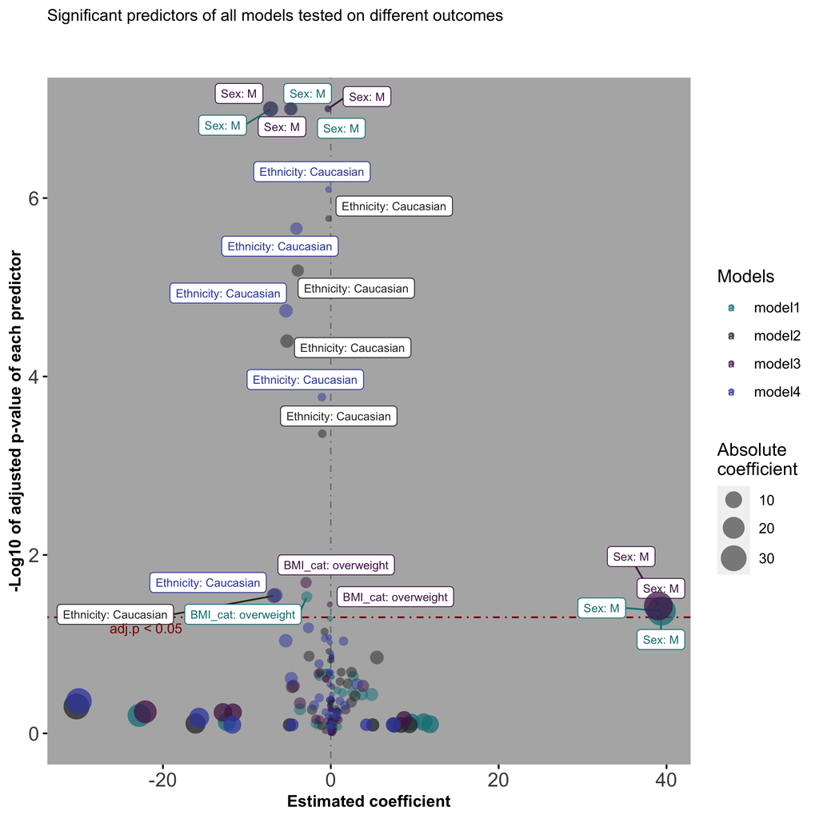

```r
Master.table1 = rbind(Model1, Model2, Model3, Model4)
All.vol.1 = ggplot(data     = Master.table1,
                   aes(x    = Estimate,       y   = -log10(var.P.adj + 0.0000001),
                      color = No.model,
                      size = abs(Estimate))
                 ) +
            geom_vline(xintercept=c(0, 0), col="gray50", lwd = 0.4, lty = 4) +
            geom_hline(yintercept=-log10(0.05+ 0.0000001), col="red4", lwd = 0.5, lty = 4) +
            geom_label_repel(aes(label = ifelse(var.P.adj < 0.05  ,New.Predictors, "")), size = 2.5, max.overlaps = 20) +
            geom_point(aes(), shape = 16, alpha = 0.5) +
            scale_color_manual(values   = c("#138086", "gray20", "#522157", "#3C4CAD"), guides("Models")) +
            scale_size(range = c(1, 8), guides("Absolute \ncoefficient")) +
            annotate(geom  = "text", x = -22, y  =1.18 , color = "red4", size = 3,
                   label = "adj.p < 0.05",
                   )+
            ggtitle("Significant predictors of all models tested on different outcomes",
            subtitle ="\n"
          ) +
            theme( panel.background = element_rect(fill = "gray70"),
                   plot.title    = element_text(size = 10),
                   panel.grid.major = element_blank(),
                   panel.grid.minor = element_blank(),
                   axis.line        = element_blank())

All.vol.1 = ggpar(All.vol.1,
                  legend = "right",
                  font.x = c(10, "bold", "black"),
                  font.y = c(10, "bold", "black"),
                  xlab= "Estimated coefficient",
                  ylab= "-Log10 of adjusted p-value of each predictor",
                  font.tickslab = c(12)
                  )


All.vol.1
```

```r
knitr::kable(Master.table1,
             row.names = F, align="c")  %>%
  kable_styling(bootstrap_options = c("striped", "hover", "condensed", "responsive")) %>%
  row_spec(which(Master.table1$var.P.adj < 0.05), bold = T, color = "Seagreen")
```

Estimate

Std. Error

Pr(>|t|)

adj.R-squared

overall.p

AIC

dependent.var

predictors

var.P.adj

star

No.model

New.Predictors

0.0718939

0.0489548

0.1447013

0.3477956

0.0000000

-6.390776

PCo1

DrugDTG

0.2315221

model1

Drug: DTG

0.1275257

0.0863110

0.1422950

0.3477956

0.0000000

-6.390776

PCo1

DrugOther

0.2315221

model1

Drug: Other

-0.0016250

0.0428431

0.9698110

0.3477956

0.0000000

-6.390776

PCo1

weight.gain_catlose

0.9698110

model1

Weight loss

-0.0134714

0.0557480

0.8094873

0.3477956

0.0000000

-6.390776

PCo1

BMI_catobese

0.9251283

model1

BMI_cat: obese

-0.1136866

0.0479582

0.0194409

0.3477956

0.0000000

-6.390776

PCo1

BMI_catoverweight

0.0518424

model1

BMI_cat: overweight

0.0136377

0.0424176

0.7484127

0.3477956

0.0000000

-6.390776

PCo1

Age_catyoung

0.9251283

model1

Age_cat: young

-0.3324128

0.0441515

0.0000000

0.3477956

0.0000000

-6.390776

PCo1

SexM

0.0000000

***

model1

Sex: M

-0.0424798

0.0355564

0.2346781

0.0139505

0.2844805

-84.416223

PCo2

DrugDTG

0.4693562

model1

Drug: DTG

-0.0780799

0.0626886

0.2154951

0.0139505

0.2844805

-84.416223

PCo2

DrugOther

0.4693562

model1

Drug: Other

0.0326691

0.0311174

0.2960010

0.0139505

0.2844805

-84.416223

PCo2

weight.gain_catlose

0.4736016

model1

Weight loss

0.0677120

0.0404904

0.0972079

0.0139505

0.2844805

-84.416223

PCo2

BMI_catobese

0.4693562

model1

BMI_cat: obese

-0.0132189

0.0348326

0.7050249

0.0139505

0.2844805

-84.416223

PCo2

BMI_catoverweight

0.7120631

model1

BMI_cat: overweight

-0.0478839

0.0308084

0.1228970

0.0139505

0.2844805

-84.416223

PCo2

Age_catyoung

0.4693562

model1

Age_cat: young

-0.0118653

0.0320678

0.7120631

0.0139505

0.2844805

-84.416223

PCo2

SexM

0.7120631

model1

Sex: M

0.6521874

0.8126878

0.4239297

0.2895412

0.0000001

679.114896

Log2.A/P

DrugDTG

0.6782875

model1

Drug: DTG

2.6890111

1.4328290

0.0631140

0.2895412

0.0000001

679.114896

Log2.A/P

DrugOther

0.2304035

model1

Drug: Other

0.4479161

0.7112282

0.5300999

0.2895412

0.0000001

679.114896

Log2.A/P

weight.gain_catlose

0.7067999

model1

Weight loss

0.1256418

0.9254596

0.8922492

0.2895412

0.0000001

679.114896

Log2.A/P

BMI_catobese

0.8922492

model1

BMI_cat: obese

-1.3770417

0.7961437

0.0864013

0.2895412

0.0000001

679.114896

Log2.A/P

BMI_catoverweight

0.2304035

model1

BMI_cat: overweight

-0.2830821

0.7041646

0.6884285

0.2895412

0.0000001

679.114896

Log2.A/P

Age_catyoung

0.7867754

model1

Age_cat: young

-4.6860459

0.7329498

0.0000000

0.2895412

0.0000001

679.114896

Log2.A/P

SexM

0.0000000

***

model1

Sex: M

1.3981780

1.1299121

0.2184732

0.3249283

0.0000000

759.524635

Log2.B/P

DrugDTG

0.3495571

model1

Drug: DTG

2.5967393

1.9921190

0.1950284

0.3249283

0.0000000

759.524635

Log2.B/P

DrugOther

0.3495571

model1

Drug: Other

-0.3326288

0.9888488

0.7372029

0.3249283

0.0000000

759.524635

Log2.B/P

weight.gain_catlose

0.8425176

model1

Weight loss

0.1918871

1.2867032

0.8817139

0.3249283

0.0000000

759.524635

Log2.B/P

BMI_catobese

0.8817139

model1

BMI_cat: obese

-2.8597310

1.1069101

0.0110437

0.3249283

0.0000000

759.524635

Log2.B/P

BMI_catoverweight

0.0294499

model1

BMI_cat: overweight

0.4385244

0.9790280

0.6550624

0.3249283

0.0000000

759.524635

Log2.B/P

Age_catyoung

0.8425176

model1

Age_cat: young

-7.1084205

1.0190492

0.0000000

0.3249283

0.0000000

759.524635

Log2.B/P

SexM

0.0000000

***

model1

Sex: M

0.0939198

0.2896807

0.7463668

0.0285194

0.1716640

427.412387

Log2.F/B

DrugDTG

0.8897737

model1

Drug: DTG

0.7924067

0.5107286

0.1235484

0.0285194

0.1716640

427.412387

Log2.F/B

DrugOther

0.3294624

model1

Drug: Other

-0.1054071

0.2535157

0.6783517

0.0285194

0.1716640

427.412387

Log2.F/B

weight.gain_catlose

0.8897737

model1

Weight loss

-0.6596047

0.3298780

0.0479281

0.0285194

0.1716640

427.412387

Log2.F/B

BMI_catobese

0.2077000

model1

BMI_cat: obese

0.0394177

0.2837836

0.8897737

0.0285194

0.1716640

427.412387

Log2.F/B

BMI_catoverweight

0.8897737

model1

BMI_cat: overweight

0.0822368

0.2509979

0.7437853

0.0285194

0.1716640

427.412387

Log2.F/B

Age_catyoung

0.8897737

model1

Age_cat: young

-0.5131986

0.2612583

0.0519250

0.0285194

0.1716640

427.412387

Log2.F/B

SexM

0.2077000

model1

Sex: M

11.0768427

16.8169083

0.5114339

0.0427475

0.0996335

1418.384417

Phylo.diver

DrugDTG

0.7462573

model1

Drug: DTG

11.8119015

29.6494602

0.6910915

0.0427475

0.0996335

1418.384417

Phylo.diver

DrugOther

0.7898189

model1

Drug: Other

-12.3758450

14.7174109

0.4021653

0.0427475

0.0996335

1418.384417

Phylo.diver

weight.gain_catlose

0.7462573

model1

Weight loss

-22.8312787

19.1504905

0.2356573

0.0427475

0.0996335

1418.384417

Phylo.diver

BMI_catobese

0.6284195

model1

BMI_cat: obese

9.6378853

16.4745619

0.5596930

0.0427475

0.0996335

1418.384417

Phylo.diver

BMI_catoverweight

0.7462573

model1

BMI_cat: overweight

-0.0375946

14.5712433

0.9979459

0.0427475

0.0996335

1418.384417

Phylo.diver

Age_catyoung

0.9979459

model1

Age_cat: young

39.3820513

15.1668938

0.0106557

0.0427475

0.0996335

1418.384417

Phylo.diver

SexM

0.0426228

model1

Sex: M

4.8692313

2.8861015

0.0943127

0.0028007

0.4015793

988.339736

InvSimpson

DrugDTG

0.3669272

model1

Drug: DTG

0.2830653

5.0884116

0.9557344

0.0028007

0.4015793

988.339736

InvSimpson

DrugOther

0.9557344

model1

Drug: Other

0.8631274

2.5257878

0.7331862

0.0028007

0.4015793

988.339736

InvSimpson

weight.gain_catlose

0.8379271

model1

Weight loss

-3.6574699

3.2865886

0.2681153

0.0028007

0.4015793

988.339736

InvSimpson

BMI_catobese

0.5362306

model1

BMI_cat: obese

-1.4648693

2.8273483

0.6053876

0.0028007

0.4015793

988.339736

InvSimpson

BMI_catoverweight

0.8071835

model1

BMI_cat: overweight

3.7393162

2.5007026

0.1375977

0.0028007

0.4015793

988.339736

InvSimpson

Age_catyoung

0.3669272

model1

Age_cat: young

-1.8304931

2.6029276

0.4833375

0.0028007

0.4015793

988.339736

InvSimpson

SexM

0.7733400

model1

Sex: M

11.0768427

16.8169083

0.5114339

0.0427475

0.0996335

1418.384417

Observed ASV

DrugDTG

0.7462573

model1

Drug: DTG

11.8119015

29.6494602

0.6910915

0.0427475

0.0996335

1418.384417

Observed ASV

DrugOther

0.7898189

model1

Drug: Other

-12.3758450

14.7174109

0.4021653

0.0427475

0.0996335

1418.384417

Observed ASV

weight.gain_catlose

0.7462573

model1

Weight loss

-22.8312787

19.1504905

0.2356573

0.0427475

0.0996335

1418.384417

Observed ASV

BMI_catobese

0.6284195

model1

BMI_cat: obese

9.6378853

16.4745619

0.5596930

0.0427475

0.0996335

1418.384417

Observed ASV

BMI_catoverweight

0.7462573

model1

BMI_cat: overweight

-0.0375946

14.5712433

0.9979459

0.0427475

0.0996335

1418.384417

Observed ASV

Age_catyoung

0.9979459

model1

Age_cat: young

39.3820513

15.1668938

0.0106557

0.0427475

0.0996335

1418.384417

Observed ASV

SexM

0.0426228

model1

Sex: M

0.1513314

0.1209053

0.2132587

-0.0132261

0.6099953

214.212064

Shannon

DrugDTG

0.4265174

model1

Drug: DTG

0.1641156

0.2131650

0.4429522

-0.0132261

0.6099953

214.212064

Shannon

DrugOther

0.7087235

model1

Drug: Other

-0.0215424

0.1058109

0.8390344

-0.0132261

0.6099953

214.212064

Shannon

weight.gain_catlose

0.8390344

model1

Weight loss

-0.2020610

0.1376826

0.1449704

-0.0132261

0.6099953

214.212064

Shannon

BMI_catobese

0.4265174

model1

BMI_cat: obese

-0.0531167

0.1184440

0.6546768

-0.0132261

0.6099953

214.212064

Shannon

BMI_catoverweight

0.7482021

model1

BMI_cat: overweight

0.1465868

0.1047601

0.1644494

-0.0132261

0.6099953

214.212064

Shannon

Age_catyoung

0.4265174

model1

Age_cat: young

-0.0534187

0.1090425

0.6251542

-0.0132261

0.6099953

214.212064

Shannon

SexM

0.7482021

model1

Sex: M

0.1024747

0.0533059

0.0570524

0.2306773

0.0000038

13.757823

PCo1

DrugDTG

0.1521397

model2

Drug: DTG

0.1169442

0.0941303

0.2166514

0.2306773

0.0000038

13.757823

PCo1

DrugOther

0.4257373

model2

Drug: Other

0.0516787

0.0467224

0.2710203

0.2306773

0.0000038

13.757823

PCo1

weight.gain_catlose

0.4257373

model2

Weight loss

0.0112923

0.0602618

0.8516895

0.2306773

0.0000038

13.757823

PCo1

BMI_catobese

0.8516895

model2

BMI_cat: obese

-0.1034492

0.0520817

0.0494011

0.2306773

0.0000038

13.757823

PCo1

BMI_catoverweight

0.1521397

model2

BMI_cat: overweight

0.0227607

0.0461168

0.6225779

0.2306773

0.0000038

13.757823

PCo1

Age_catyoung

0.7115176

model2

Age_cat: young

-0.2600056

0.0469258

0.0000002

0.2306773

0.0000038

13.757823

PCo1

EthnicityCaucasian

0.0000016

***

model2

Ethnicity: Caucasian

-0.0480710

0.0349060

0.1711627

0.0545743

0.0613299

-89.548910

PCo2

DrugDTG

0.4564339

model2

Drug: DTG

-0.0593228

0.0616388

0.3378723

0.0545743

0.0613299

-89.548910

PCo2

DrugOther

0.5403321

model2

Drug: Other

0.0255585

0.0305949

0.4052491

0.0545743

0.0613299

-89.548910

PCo2

weight.gain_catlose

0.5403321

model2

Weight loss

0.0844118

0.0394609

0.0345588

0.0545743

0.0613299

-89.548910

PCo2

BMI_catobese

0.1382352

model2

BMI_cat: obese

-0.0008686

0.0341044

0.9797265

0.0545743

0.0613299

-89.548910

PCo2

BMI_catoverweight

0.9797265

model2

BMI_cat: overweight

-0.0342779

0.0301984

0.2587191

0.0545743

0.0613299

-89.548910

PCo2

Age_catyoung

0.5174382

model2

Age_cat: young

0.0689930

0.0307282

0.0266795

0.0545743

0.0613299

-89.548910

PCo2

EthnicityCaucasian

0.1382352

model2

Ethnicity: Caucasian

1.1058796

0.8526918

0.1972749

0.2218914

0.0000068

690.211420

Log2.A/P

DrugDTG

0.2630332

model2

Drug: DTG

2.4751489

1.5057264

0.1029677

0.2218914

0.0000068

690.211420

Log2.A/P

DrugOther

0.2059354

model2

Drug: Other

1.2298147

0.7473798

0.1026209

0.2218914

0.0000068

690.211420

Log2.A/P

weight.gain_catlose

0.2059354

model2

Weight loss

0.4212650

0.9639589

0.6629268

0.2218914

0.0000068

690.211420

Log2.A/P

BMI_catobese

0.7576306

model2

BMI_cat: obese

-1.2732448

0.8331096

0.1292071

0.2218914

0.0000068

690.211420

Log2.A/P

BMI_catoverweight

0.2067314

model2

BMI_cat: overweight

-0.1993750

0.7376930

0.7874426

0.2218914

0.0000068

690.211420

Log2.A/P

Age_catyoung

0.7874426

model2

Age_cat: young

-3.9299557

0.7506349

0.0000008

0.2218914

0.0000068

690.211420

Log2.A/P

EthnicityCaucasian

0.0000064

***

model2

Ethnicity: Caucasian

2.0222027

1.2344349

0.1041454

0.1983930

0.0000303

780.484188

Log2.B/P

DrugDTG

0.2777211

model2

Drug: DTG

2.4561385

2.1798276

0.2622109

0.1983930

0.0000303

780.484188

Log2.B/P

DrugOther

0.4488165

model2

Drug: Other

0.7668760

1.0819755

0.4799117

0.1983930

0.0000303

780.484188

Log2.B/P

weight.gain_catlose

0.5713427

model2

Weight loss

0.7922595

1.3955153

0.5713427

0.1983930

0.0000303

780.484188

Log2.B/P

BMI_catobese

0.5713427

model2

BMI_cat: obese

-2.5871476

1.2060859

0.0340689

0.1983930

0.0000303

780.484188

Log2.B/P

BMI_catoverweight

0.1362756

model2

BMI_cat: overweight

0.6930776

1.0679521

0.5176578

0.1983930

0.0000303

780.484188

Log2.B/P

Age_catyoung

0.5713427

model2

Age_cat: young

-5.2095610

1.0866879

0.0000050

0.1983930

0.0000303

780.484188

Log2.B/P

EthnicityCaucasian

0.0000400

***

model2

Ethnicity: Caucasian

0.1934801

0.2748666

0.4829270

0.1298314

0.0016163

413.976004

Log2.F/B

DrugDTG

0.7726832

model2

Drug: DTG

0.6261817

0.4853733

0.1996256

0.1298314

0.0016163

413.976004

Log2.F/B

DrugOther

0.5323349

model2

Drug: Other

0.0474897

0.2409191

0.8440856

0.1298314

0.0016163

413.976004

Log2.F/B

weight.gain_catlose

0.9741981

model2

Weight loss

-0.7452637

0.3107337

0.0180897

0.1298314

0.0016163

413.976004

Log2.F/B

BMI_catobese

0.0723588

model2

BMI_cat: obese

-0.0386587

0.2685542

0.8857931

0.1298314

0.0016163

413.976004

Log2.F/B

BMI_catoverweight

0.9741981

model2

BMI_cat: overweight

-0.0077081

0.2377965

0.9741981

0.1298314

0.0016163

413.976004

Log2.F/B

Age_catyoung

0.9741981

model2

Age_cat: young

-1.0145560

0.2419684

0.0000547

0.1298314

0.0016163

413.976004

Log2.F/B

EthnicityCaucasian

0.0004376

***

model2

Ethnicity: Caucasian

9.3679775

17.3287197

0.5898352

-0.0111875

0.5817441

1425.071658

Phylo.diver

DrugDTG

0.8046817

model2

Drug: DTG

7.5847718

30.5999295

0.8046817

-0.0111875

0.5817441

1425.071658

Phylo.diver

DrugOther

0.8046817

model2

Drug: Other

-16.1092565

15.1885292

0.2911046

-0.0111875

0.5817441

1425.071658

Phylo.diver

weight.gain_catlose

0.7762789

model2

Weight loss

-30.2952498

19.5899305

0.1247626

-0.0111875

0.5817441

1425.071658

Phylo.diver

BMI_catobese

0.4990504

model2

BMI_cat: obese

4.9921964

16.9307628

0.7686375

-0.0111875

0.5817441

1425.071658

Phylo.diver

BMI_catoverweight

0.8046817

model2

BMI_cat: overweight

-4.9223194

14.9916709

0.7432592

-0.0111875

0.5817441

1425.071658

Phylo.diver

Age_catyoung

0.8046817

model2

Age_cat: young

8.3837738

15.2546801

0.5836777

-0.0111875

0.5817441

1425.071658

Phylo.diver

EthnicityCaucasian

0.8046817

model2

Ethnicity: Caucasian

5.4934615

2.8089069

0.0529438

0.0602810

0.0480585

981.096626

InvSimpson

DrugDTG

0.1411835

model2

Drug: DTG

-1.0803928

4.9601099

0.8279616

0.0602810

0.0480585

981.096626

InvSimpson

DrugOther

0.8279616

model2

Drug: Other

1.7714488

2.4619918

0.4732939

0.0602810

0.0480585

981.096626

InvSimpson

weight.gain_catlose

0.5409073

model2

Weight loss

-4.5999102

3.1754390

0.1501970

0.0602810

0.0480585

981.096626

InvSimpson

BMI_catobese

0.3003940

model2

BMI_cat: obese

-2.2259901

2.7443999

0.4189969

0.0602810

0.0480585

981.096626

InvSimpson

BMI_catoverweight

0.5409073

model2

BMI_cat: overweight

2.8836935

2.4300819

0.2378268

0.0602810

0.0480585

981.096626

InvSimpson

Age_catyoung

0.3805229

model2

Age_cat: young

-6.7708600

2.4727145

0.0071694

0.0602810

0.0480585

981.096626

InvSimpson

EthnicityCaucasian

0.0286776

model2

Ethnicity: Caucasian

9.3679775

17.3287197

0.5898352

-0.0111875

0.5817441

1425.071658

Observed ASV

DrugDTG

0.8046817

model2

Drug: DTG

7.5847718

30.5999295

0.8046817

-0.0111875

0.5817441

1425.071658

Observed ASV

DrugOther

0.8046817

model2

Drug: Other

-16.1092565

15.1885292

0.2911046

-0.0111875

0.5817441

1425.071658

Observed ASV

weight.gain_catlose

0.7762789

model2

Weight loss

-30.2952498

19.5899305

0.1247626

-0.0111875

0.5817441

1425.071658

Observed ASV

BMI_catobese

0.4990504

model2

BMI_cat: obese

4.9921964

16.9307628

0.7686375

-0.0111875

0.5817441

1425.071658

Observed ASV

BMI_catoverweight

0.8046817

model2

BMI_cat: overweight

-4.9223194

14.9916709

0.7432592

-0.0111875

0.5817441

1425.071658

Observed ASV

Age_catyoung

0.8046817

model2

Age_cat: young

8.3837738

15.2546801

0.5836777

-0.0111875

0.5817441

1425.071658

Observed ASV

EthnicityCaucasian

0.8046817

model2

Ethnicity: Caucasian

0.1722890

0.1188581

0.1499335

0.0258230

0.1892847

209.417259

Shannon

DrugDTG

0.2998670

model2

Drug: DTG

0.1164780

0.2098856

0.5800096

0.0258230

0.1892847

209.417259

Shannon

DrugOther

0.6628681

model2

Drug: Other

0.0086617

0.1041785

0.9338841

0.0258230

0.1892847

209.417259

Shannon

weight.gain_catlose

0.9338841

model2

Weight loss

-0.2360508

0.1343678

0.0816452

0.0258230

0.1892847

209.417259

Shannon

BMI_catobese

0.2177205

model2

BMI_cat: obese

-0.0802438

0.1161285

0.4909753

0.0258230

0.1892847

209.417259

Shannon

BMI_catoverweight

0.6546337

model2

BMI_cat: overweight

0.1161705

0.1028282

0.2609518

0.0258230

0.1892847

209.417259

Shannon

Age_catyoung

0.4175229

model2

Age_cat: young

-0.2296960

0.1046322

0.0301706

0.0258230

0.1892847

209.417259

Shannon

EthnicityCaucasian

0.1206824

model2

Ethnicity: Caucasian

-0.0340883

0.0449079

0.4493628

0.3396730

0.0000000

-6.148067

PCo1

BackBoneTAF

0.7863849

model3

BackBone: TAF

0.0137352

0.0419648

0.7440344

0.3396730

0.0000000

-6.148067

PCo1

weight.gain_catlose

0.9324263

model3

Weight loss

-0.0047385

0.0557617

0.9324263

0.3396730

0.0000000

-6.148067

PCo1

BMI_catobese

0.9324263

model3

BMI_cat: obese

-0.1180047

0.0479687

0.0153798

0.3396730

0.0000000

-6.148067

PCo1

BMI_catoverweight

0.0358862

model3

BMI_cat: overweight

0.0050181

0.0424995

0.9062150

0.3396730

0.0000000

-6.148067

PCo1

Age_catyoung

0.9324263

model3

Age_cat: young

-0.3370932

0.0442731

0.0000000

0.3396730

0.0000000

-6.148067

PCo1

SexM

0.0000000

***

model3

Sex: M

0.0283981

0.0324587

0.3834512

0.0113466

0.2953601

-85.361778

PCo2

BackBoneTAF

0.7378651

model3

BackBone: TAF

0.0244614

0.0303315

0.4216372

0.0113466

0.2953601

-85.361778

PCo2

weight.gain_catlose

0.7378651

model3

Weight loss

0.0624376

0.0403036

0.1240858

0.0113466

0.2953601

-85.361778

PCo2

BMI_catobese

0.5395596

model3

BMI_cat: obese

-0.0094936

0.0346710

0.7847146

0.0113466

0.2953601

-85.361778

PCo2

BMI_catoverweight

0.9155004

model3

BMI_cat: overweight

-0.0440630

0.0307179

0.1541599

0.0113466

0.2953601

-85.361778

PCo2

Age_catyoung

0.5395596

model3

Age_cat: young

-0.0089888

0.0319998

0.7792910

0.0113466

0.2953601

-85.361778

PCo2

SexM

0.9155004

model3

Sex: M

-0.0627973

0.7489659

0.9333251

0.2740010

0.0000001

680.487400

Log2.A/P

BackBoneTAF

0.9333251

model3

BackBone: TAF

0.7447155

0.6998821

0.2895313

0.2740010

0.0000001

680.487400

Log2.A/P

weight.gain_catlose

0.6755730

model3

Weight loss

0.3142223

0.9299841

0.7360702

0.2740010

0.0000001

680.487400

Log2.A/P

BMI_catobese

0.8587486

model3

BMI_cat: obese

-1.5126285

0.8000141

0.0611739

0.2740010

0.0000001

680.487400

Log2.A/P

BMI_catoverweight

0.2141086

model3

BMI_cat: overweight

-0.4612183

0.7087988

0.5165354

0.2740010

0.0000001

680.487400

Log2.A/P

Age_catyoung

0.7231496

model3

Age_cat: young

-4.7983508

0.7383784

0.0000000

0.2740010

0.0000001

680.487400

Log2.A/P

SexM

0.0000000

***

model3

Sex: M

-0.6082602

1.0341275

0.5575603

0.3196549

0.0000000

759.206660

Log2.B/P

BackBoneTAF

0.9252801

model3

BackBone: TAF

-0.0171752

0.9663555

0.9858506

0.3196549

0.0000000

759.206660

Log2.B/P

weight.gain_catlose

0.9858506

model3

Weight loss

0.3703789

1.2840667

0.7735276

0.3196549

0.0000000

759.206660

Log2.B/P

BMI_catobese

0.9252801

model3

BMI_cat: obese

-2.9469093

1.1046118

0.0087365

0.3196549

0.0000000

759.206660

Log2.B/P

BMI_catoverweight

0.0203852

model3

BMI_cat: overweight

0.2572927

0.9786671

0.7930972

0.3196549

0.0000000

759.206660

Log2.B/P

Age_catyoung

0.9252801

model3

Age_cat: young

-7.2048172

1.0195089

0.0000000

0.3196549

0.0000000

759.206660

Log2.B/P

SexM

0.0000000

***

model3

Sex: M

0.0588547

0.2658290

0.8251731

0.0157165

0.2529430

427.742396

Log2.F/B

BackBoneTAF

0.9851698

model3

BackBone: TAF

-0.0206660

0.2484078

0.9338419

0.0157165

0.2529430

427.742396

Log2.F/B

weight.gain_catlose

0.9851698

model3

Weight loss

-0.6035029

0.3300774

0.0700862

0.0157165

0.2529430

427.742396

Log2.F/B

BMI_catobese

0.2453017

model3

BMI_cat: obese

-0.0052895

0.2839474

0.9851698

0.0157165

0.2529430

427.742396

Log2.F/B

BMI_catoverweight

0.9851698

model3

BMI_cat: overweight

0.0296992

0.2515726

0.9062308

0.0157165

0.2529430

427.742396

Log2.F/B

Age_catyoung

0.9851698

model3

Age_cat: young

-0.5478459

0.2620712

0.0387810

0.0157165

0.2529430

427.742396

Log2.F/B

SexM

0.2453017

model3

Sex: M

-12.8518797

15.2477192

0.4010495

0.0531864

0.0547643

1415.779397

Phylo.diver

BackBoneTAF

0.5812492

model3

BackBone: TAF

-11.6519983

14.2484530

0.4151780

0.0531864

0.0547643

1415.779397

Phylo.diver

weight.gain_catlose

0.5812492

model3

Weight loss

-22.1036863

18.9329538

0.2454349

0.0531864

0.0547643

1415.779397

Phylo.diver

BMI_catobese

0.5726814

model3

BMI_cat: obese

8.7351040

16.2869773

0.5927703

0.0531864

0.0547643

1415.779397

Phylo.diver

BMI_catoverweight

0.6915653

model3

BMI_cat: overweight

0.2028362

14.4299825

0.9888092

0.0531864

0.0547643

1415.779397

Phylo.diver

Age_catyoung

0.9888092

model3

Age_cat: young

39.0279104

15.0321747

0.0106531

0.0531864

0.0547643

1415.779397

Phylo.diver

SexM

0.0372859

model3

Sex: M

-4.4374134

2.6264213

0.0938276

0.0064080

0.3493480

986.630311

InvSimpson

BackBoneTAF

0.2938908

model3

BackBone: TAF

0.9412081

2.4542976

0.7020617

0.0064080

0.3493480

986.630311

InvSimpson

weight.gain_catlose

0.7020617

model3

Weight loss

-3.6695461

3.2612034

0.2628420

0.0064080

0.3493480

986.630311

InvSimpson

BMI_catobese

0.4599735

model3

BMI_cat: obese

-1.3220993

2.8054336

0.6383452

0.0064080

0.3493480

986.630311

InvSimpson

BMI_catoverweight

0.7020617

model3

BMI_cat: overweight

3.8313900

2.4855661

0.1259532

0.0064080

0.3493480

986.630311

InvSimpson

Age_catyoung

0.2938908

model3

Age_cat: young

-1.7654487

2.5892937

0.4967197

0.0064080

0.3493480

986.630311

InvSimpson

SexM

0.6954076

model3

Sex: M

-12.8518797

15.2477192

0.4010495

0.0531864

0.0547643

1415.779397

Observed ASV

BackBoneTAF

0.5812492

model3

BackBone: TAF

-11.6519983

14.2484530

0.4151780

0.0531864

0.0547643

1415.779397

Observed ASV

weight.gain_catlose

0.5812492

model3

Weight loss

-22.1036863

18.9329538

0.2454349

0.0531864

0.0547643

1415.779397

Observed ASV

BMI_catobese

0.5726814

model3

BMI_cat: obese

8.7351040

16.2869773

0.5927703

0.0531864

0.0547643

1415.779397

Observed ASV

BMI_catoverweight

0.6915653

model3

BMI_cat: overweight

0.2028362

14.4299825

0.9888092

0.0531864

0.0547643

1415.779397

Observed ASV

Age_catyoung

0.9888092

model3

Age_cat: young

39.0279104

15.0321747

0.0106531

0.0531864

0.0547643

1415.779397

Observed ASV

SexM

0.0372859

model3

Sex: M

-0.1195006

0.1099630

0.2794266

-0.0083924

0.5474301

212.361354

Shannon

BackBoneTAF

0.4889966

model3

BackBone: TAF

-0.0040217

0.1027565

0.9688478

-0.0083924

0.5474301

212.361354

Shannon

weight.gain_catlose

0.9688478

model3

Weight loss

-0.1914109

0.1365401

0.1636486

-0.0083924

0.5474301

212.361354

Shannon

BMI_catobese

0.4197669

model3

BMI_cat: obese

-0.0592106

0.1174579

0.6151549

-0.0083924

0.5474301

212.361354

Shannon

BMI_catoverweight

0.7176807

model3

BMI_cat: overweight

0.1404129

0.1040657

0.1799001

-0.0083924

0.5474301

212.361354

Shannon

Age_catyoung

0.4197669

model3

Age_cat: young

-0.0584675

0.1084086

0.5907049

-0.0083924

0.5474301

212.361354

Shannon

SexM

0.7176807

model3

Sex: M

-0.0721745

0.0490720

0.1440797

0.2257341

0.0000029

13.271916

PCo1

BackBoneTAF

0.2073746

model4

BackBone: TAF

0.0661453

0.0454303

0.1481247

0.2257341

0.0000029

13.271916

PCo1

weight.gain_catlose

0.2073746

model4

Weight loss

0.0185266

0.0601348

0.7585756

0.2257341

0.0000029

13.271916

PCo1

BMI_catobese

0.7585756

model4

BMI_cat: obese

-0.1072767

0.0519047

0.0409977

0.2257341

0.0000029

13.271916

PCo1

BMI_catoverweight

0.0956613

model4

BMI_cat: overweight

0.0163883

0.0459744

0.7221458

0.2257341

0.0000029

13.271916

PCo1

Age_catyoung

0.7585756

model4

Age_cat: young

-0.2661834

0.0466786

0.0000001

0.2257341

0.0000029

13.271916

PCo1

EthnicityCaucasian

0.0000007

***

model4

Ethnicity: Caucasian

0.0386718

0.0319768

0.2290003

0.0577618

0.0445152

-91.228228

PCo2

BackBoneTAF

0.4007505

model4

BackBone: TAF

0.0189184

0.0296037

0.5240577

0.0577618

0.0445152

-91.228228

PCo2

weight.gain_catlose

0.6114006

model4

Weight loss

0.0809320

0.0391856

0.0411373

0.0577618

0.0445152

-91.228228

PCo2

BMI_catobese

0.1439806

model4

BMI_cat: obese

0.0019448

0.0338226

0.9542458

0.0577618

0.0445152

-91.228228

PCo2

BMI_catoverweight

0.9542458

model4

BMI_cat: overweight

-0.0317708

0.0299583

0.2911395

0.0577618

0.0445152

-91.228228

PCo2

Age_catyoung

0.4075953

model4

Age_cat: young

0.0729235

0.0304172

0.0181202

0.0577618

0.0445152

-91.228228

PCo2

EthnicityCaucasian

0.1268414

model4

Ethnicity: Caucasian

-0.6478896

0.7873835

0.4123027

0.2120600

0.0000073

690.475944

Log2.A/P

BackBoneTAF

0.5772238

model4

BackBone: TAF

1.5171554

0.7289508

0.0396273

0.2120600

0.0000073

690.475944

Log2.A/P

weight.gain_catlose

0.0924637

model4

Weight loss

0.5773803

0.9648912

0.5507571

0.2120600

0.0000073

690.475944

Log2.A/P

BMI_catobese

0.6409097

model4

BMI_cat: obese

-1.4023544

0.8328346

0.0949265

0.2120600

0.0000073

690.475944

Log2.A/P

BMI_catoverweight

0.1661214

model4

BMI_cat: overweight

-0.3449872

0.7376813

0.6409097

0.2120600

0.0000073

690.475944

Log2.A/P

Age_catyoung

0.6409097

model4

Age_cat: young

-4.0934611

0.7489800

0.0000003

0.2120600

0.0000073

690.475944

Log2.A/P

EthnicityCaucasian

0.0000021

***

model4

Ethnicity: Caucasian

-1.3728513

1.1349230

0.2288968

0.1953213

0.0000216

779.683483

Log2.B/P

BackBoneTAF

0.4005694

model4

BackBone: TAF

1.0726118

1.0506989

0.3094656

0.1953213

0.0000216

779.683483

Log2.B/P

weight.gain_catlose

0.4332518

model4

Weight loss

0.9459084

1.3907799

0.4977903

0.1953213

0.0000216

779.683483

Log2.B/P

BMI_catobese

0.5807554

model4

BMI_cat: obese

-2.6687761

1.2004356

0.0281588

0.1953213

0.0000216

779.683483

Log2.B/P

BMI_catoverweight

0.0657039

model4

BMI_cat: overweight

0.5528152

1.0632829

0.6041232

0.1953213

0.0000216

779.683483

Log2.B/P

Age_catyoung

0.6041232

model4

Age_cat: young

-5.3388007

1.0795688

0.0000026

0.1953213

0.0000216

779.683483

Log2.B/P

EthnicityCaucasian

0.0000182

***

model4

Ethnicity: Caucasian

-0.0913339

0.2528422

0.7185912

0.1255736

0.0014053

413.304207

Log2.F/B

BackBoneTAF

0.8477364

model4

BackBone: TAF

0.1187912

0.2340785

0.6127868

0.1255736

0.0014053

413.304207

Log2.F/B

weight.gain_catlose

0.8477364

model4

Weight loss

-0.7054808

0.3098430

0.0246417

0.1255736

0.0014053

413.304207

Log2.F/B

BMI_catobese

0.0862460

model4

BMI_cat: obese

-0.0750741

0.2674374

0.7794322

0.1255736

0.0014053

413.304207

Log2.F/B

BMI_catoverweight

0.8477364

model4

BMI_cat: overweight

-0.0455857

0.2368820

0.8477364

0.1255736

0.0014053

413.304207

Log2.F/B

Age_catyoung

0.8477364

model4

Age_cat: young

-1.0584311

0.2405102

0.0000243

0.1255736

0.0014053

413.304207

Log2.F/B

EthnicityCaucasian

0.0001701

***

model4

Ethnicity: Caucasian

-11.7385787

15.8145397

0.4594402

-0.0001760

0.4312089

1422.468538

Phylo.diver

BackBoneTAF

0.8005013

model4

BackBone: TAF

-15.6934500

14.6409228

0.2860140

-0.0001760

0.4312089

1422.468538

Phylo.diver

weight.gain_catlose

0.6673660

model4

Weight loss

-30.0161180

19.3797686

0.1241684

-0.0001760

0.4312089

1422.468538

Phylo.diver

BMI_catobese

0.4345894

model4

BMI_cat: obese

4.2367831

16.7274233

0.8005013

-0.0001760

0.4312089

1422.468538

Phylo.diver

BMI_catoverweight

0.8005013

model4

BMI_cat: overweight

-4.6141412

14.8162744

0.7560423

-0.0001760

0.4312089

1422.468538

Phylo.diver

Age_catyoung

0.8005013

model4

Age_cat: young

7.4535507

15.0432092

0.6212096

-0.0001760

0.4312089

1422.468538

Phylo.diver

EthnicityCaucasian

0.8005013

model4

Ethnicity: Caucasian

-5.3721603

2.5755775

0.0392076

0.0617099

0.0371143

979.643678

InvSimpson

BackBoneTAF

0.0914844

model4

BackBone: TAF

1.6677340

2.3844406

0.4856996

0.0617099

0.0371143

979.643678

InvSimpson

weight.gain_catlose

0.4856996

model4

Weight loss

-4.7118499

3.1562155

0.1382072

0.0617099

0.0371143

979.643678

InvSimpson

BMI_catobese

0.2418626

model4

BMI_cat: obese

-1.9922749

2.7242509

0.4660767

0.0617099

0.0371143

979.643678

InvSimpson

BMI_catoverweight

0.4856996

model4

BMI_cat: overweight

3.1100803

2.4129986

0.2000244

0.0617099

0.0371143

979.643678

InvSimpson

Age_catyoung

0.2800342

model4

Age_cat: young

-6.6059299

2.4499575

0.0080637

0.0617099

0.0371143

979.643678

InvSimpson

EthnicityCaucasian

0.0282230

model4

Ethnicity: Caucasian

-11.7385787

15.8145397

0.4594402

-0.0001760

0.4312089

1422.468538

Observed ASV

BackBoneTAF

0.8005013

model4

BackBone: TAF

-15.6934500

14.6409228

0.2860140

-0.0001760

0.4312089

1422.468538

Observed ASV

weight.gain_catlose

0.6673660

model4

Weight loss

-30.0161180

19.3797686

0.1241684

-0.0001760

0.4312089

1422.468538

Observed ASV

BMI_catobese

0.4345894

model4

BMI_cat: obese

4.2367831

16.7274233

0.8005013

-0.0001760

0.4312089

1422.468538

Observed ASV

BMI_catoverweight

0.8005013

model4

BMI_cat: overweight

-4.6141412

14.8162744

0.7560423

-0.0001760

0.4312089

1422.468538

Observed ASV

Age_catyoung

0.8005013

model4

Age_cat: young

7.4535507

15.0432092

0.6212096

-0.0001760

0.4312089

1422.468538

Observed ASV

EthnicityCaucasian

0.8005013

model4

Ethnicity: Caucasian

-0.1529749

0.1086585

0.1618730

0.0331204

0.1294055

207.232643

Shannon

BackBoneTAF

0.2832777

model4

BackBone: TAF

0.0215869

0.1005948

0.8304651

0.0331204

0.1294055

207.232643

Shannon

weight.gain_catlose

0.8304651

model4

Weight loss

-0.2299157

0.1331545

0.0869097

0.0331204

0.1294055

207.232643

Shannon

BMI_catobese

0.2027893

model4

BMI_cat: obese

-0.0838924

0.1149308

0.4669121

0.0331204

0.1294055

207.232643

Shannon

BMI_catoverweight

0.5447308

model4

BMI_cat: overweight

0.1138511

0.1017996

0.2657336

0.0331204

0.1294055

207.232643

Shannon

Age_catyoung

0.3720270

model4

Age_cat: young

-0.2366186

0.1033589

0.0238873

0.0331204

0.1294055

207.232643

Shannon

EthnicityCaucasian

0.0836056

model4

Ethnicity: Caucasian